# R Notebook

## **Project Description**

### Term

- Spring 2017

### Team

- Group 12

### Team Members

- Kai Chen (Presenter)
- Senyao Han
- Kexin Nie
- Yini Zhang
- Chenyun Zhu

### Project Summary

In our project, we studied entity resolution through two academic papers which introduce two methods.

#### Paper 2:

- Using linear svm, with its own unique way of evaluation
- Comparing the performance of different variables through its average accuracy.

#### Paper 5:

- Error-driven machine learning with a ranking loss function.
- Features selected (6 features): cosine similarity of coauthors,papers and journals; mean Euclidean distance (word2vec) of coauthors, papers and journals.

The detailed methods we applied are as follow: Clusterwise Scoring Function as the partition criterion, Error-driven Online Training to generate training examples and Ranking Perceptron as the loss function.

## **Paper 2 Evaluation**

### Feature:

Paper, Journal, Coauthor, Paper and Journal

#### Average Accuracy:

| Paper | Journal | Coauthor | Paper and Journal |
| --- | --- | --- | --- |
| 0.7275 | 0.6458 | 0.8093 | 0.8980 |

#### SD Accuracy:

| Paper | Journal | Coauthor | Paper and Journal |
| --- | --- | --- | --- |
| 0.0901 | 0.1159 | 0.0791 | 0.0444 |

#### Average Running time (s):

| Paper | Journal | Coauthor | Paper and Journal |
| --- | --- | --- | --- |
| 5.010 | 4.293 | 1.251 | 6.897 |

## **Paper 5 Evaluation**

### Feature

- Baseline (3 features): Cosine Similarity (coauthor, paper, journal)
- Improved model (6 features): Cosine Similarity, Mean Euclidean Distance

### Algorithm

- Score function: weighted sum of cosine similarity of coauthor, paper and journal.
- Clusering predictive algorithm: bottom-up agglomerative clustering, linkage is the average distance or averaged cosine similarity, merge decision is according to maximum score.
- Parameter Update: comparison between the score of a better merge, and the score of the wrongly predicted merge.

### Baseline

#### Model Evaluation (average)

| Precision | Recall | F1 score | Accuracy |
| --- | --- | --- | --- |
| 0.2321 | 0.7956 | 0.3478 | 0.5688 |

#### Parameters of features (average)

| Cos_Coauthor | Cos_Paper | Cos_Journal |
| --- | --- | --- |
| 0.3176 | 0.4308 | 0.2516 |

### Improved Model

#### Model Evaluation (average)

| Precision | Recall | F1 score | Accuracy |
| --- | --- | --- | --- |
| 0.4433 | 0.4930 | 0.4109 | 0.7674 |

#### Parameters of features (average)

| Cos_Coauthor | Cos_Paper | Cos_Journal | dist_coauthor | dist_paper | dist_journal |
| --- | --- | --- | --- | --- | --- |
| 0.6423 | 0.5835 | -0.1141 | -0.2480 | 0.1969 | -0.0605 |

### Model Comparison

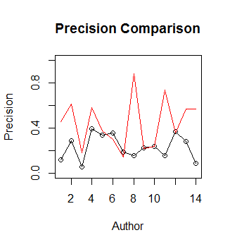

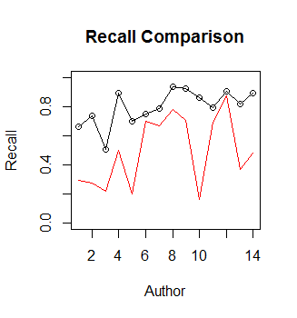

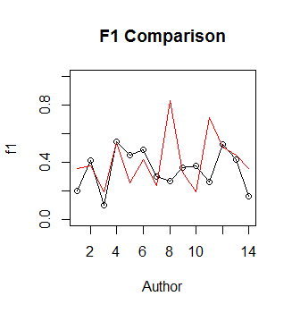

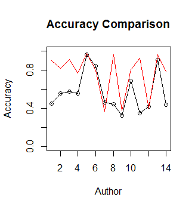